# Part II - (An Exploratory Analysis of Loan Data from Prosper)

## by (Eyong, Wofai Alfred)

## Investigation Overview

> My goal is to identify features of an individual which an investor should consider important when choosing a prosper loan to fund. These features will also help the Prosper Company minimise the occurence of high risk loans which doesnt benefit investors and the Prosper company as a whole. In summary, the lender yield as a single metric may not inform an investor about the best prosper loan to invest in. Combining the lender yield with other important metrics will help an investor make better choices on what loan to invest in and help the prosper company fund low risk loans.

## Dataset Overview

> The Prosper loan dataset has 113,937 sample entries in this mother dataset with 81 distinct attributes or characteristics. However, i analysed 14 out of the 81 attributes.

## Percentage profit as an investor

The highest possible yield on any loan is 0.492500% on the loaned amount. 0.3% has been most earned by investors, followed closely by 0.15%. On 5 loans, some investors earned -0.010%. This means that as an investor, if the right loans are not selected before investment, one could end up with losses. This business definitely generates more gains than losses for its investors, making it a viable income source.

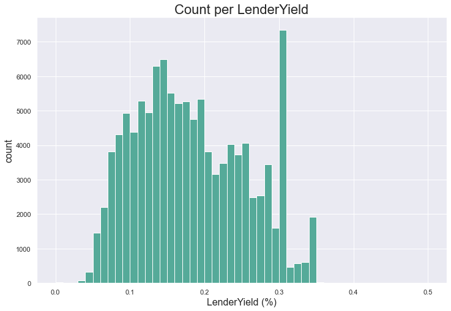

## Relationship between income and loan amount

The higher an individual's income, the higher the loan amount that can be possibly accessed.

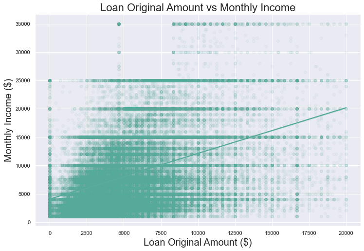

## Effect of Loan Amount on Lender Yield

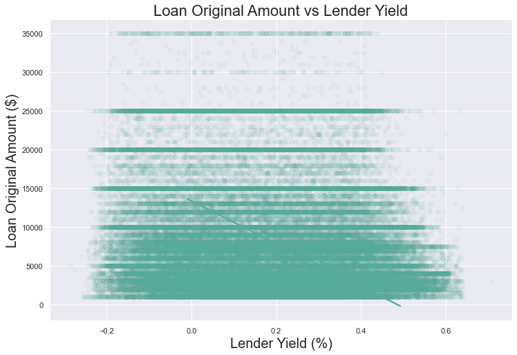

## Home ownership status and loan amount

Home owners are observed to collect significantly higher loan amounts in dollars on average, compared to non home owners, however, getting a high loan amount is still possible, without owning a home.

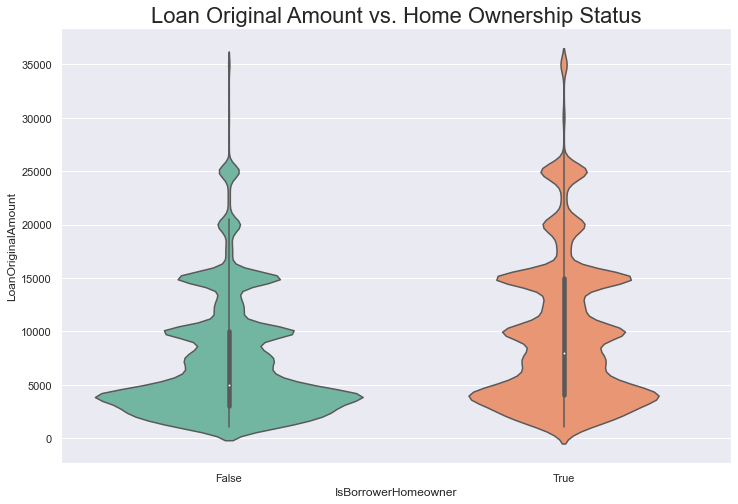

## Prosper ratings and loan amounts

High risk rated(1.0) individuals were given significantly lower loan amounts compared to higher scored individuals.

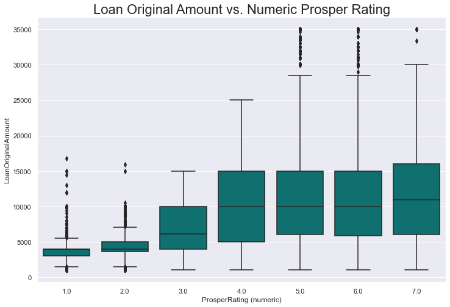

## Income Range and Loan Term

The 36 month loan duration is prefered by individuals across all income ranges.

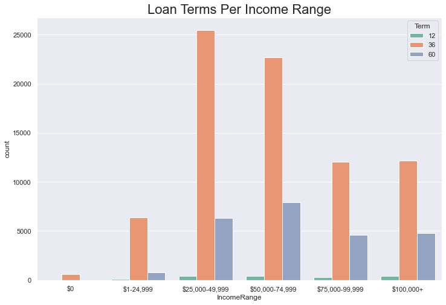

## Effect of prosper ratings on loan amount and lender yield

The loans of individuals with prosper rating 6 and 7 are the best for loan investment opportunities.

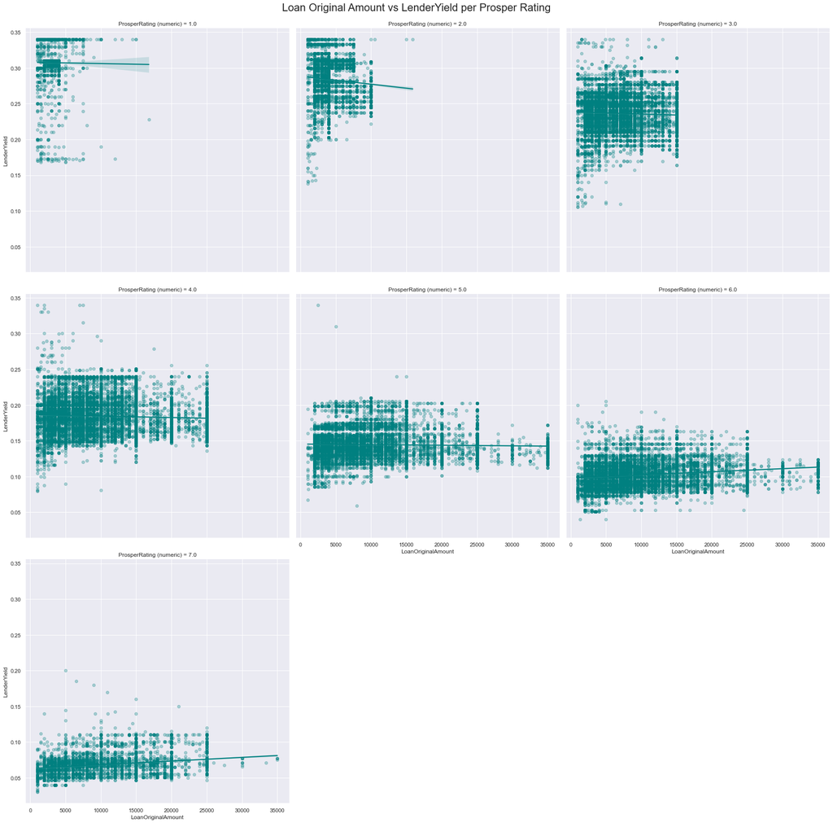

## Effect of home ownership and a high credit score on Lender Yield

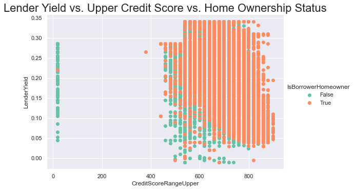

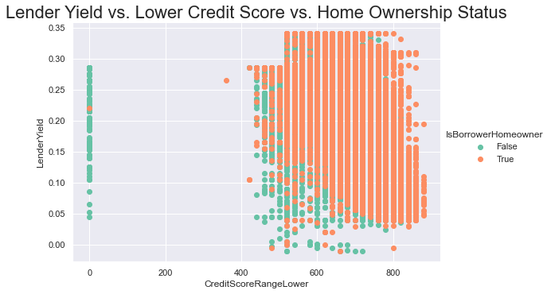

# Conclusion

After analysis of the prosper loan dataset, it is evident that confirming the lender yield, home ownership status, prosper rating, credit score range and the loan amount is necessary for an investor to choose the best loans to invest in for maximum returns. These features will also help the prosper company reduce its incidences of high risk loans.